# FLicc 1.0.10 development branch: new features and tests before merging

Henning Winker (FAO-NFI)

10 October 2026

# 1 What this document covers

This document tests the branch `dev-merge`, which combines the two development branches before they go into `main`:

| Branch | Features |
| --- | --- |
| `dev-tailcut` | `settings$tail_cut`: upper length bins excluded from the likelihood; `LBIspr()` and `LBImean()` use the same cut; MSE fixes (`trend = "track"` in the HCRs, `Cmin` in `flicc.is()`, `lfdess()` guard) |
| `dev-frw` | state-space random walk on F (`settings$F_re`), fixed `sigmaF`, `sigmaF_flicc()`, `fiticc(se = FALSE)`; CI workflow |

Every test records a pass/fail result; the table at the end lists them all, and the last chunk stops if any failed. To run it yourself, install the branch and knit this file:

```r
remotes::install_github("henning-winker/FLicc", ref = "dev-merge")
# or, in a local clone: git switch dev-merge; devtools::install()
rmarkdown::render("docs/FLicc_dev_tests.Rmd")
```

```r
library(FLicc)
packageVersion("FLicc")
```

```
#> [1] '1.0.10'
```

```r
data("alfonsino")
lfd <- FLQuantLen(lfd_long_to_wide(as.data.frame(lfd_alfonsino)), unit = "cm", midL = FALSE)
lhpar <- FLPar(linf = 55.7, k = 0.08, M = 0.162, L50 = 31.1859,
               a = 0.004721956 / 1000, b = 3.146168)
stklen <- stocklen(lfd, lhpar, m_model = "constant")

sel_fun <- c("dsnormal", "logistic")
cbg     <- c(0.7, 0.3)
base    <- list(CVL = 0.1, prior_sigmaF = c(log(0.5), 0.3, 1))

# fit with the base settings plus any extra settings
fitf <- function(..., se = TRUE) fiticc(lfd, stklen, sel_fun = sel_fun, catch_by_gear = cbg,
                                        settings = modifyList(base, list(...)), se = se)
lastspr <- function(fit) round(tail(c(fit$report$spr), 1), 4)

# record checks without stopping the document
checks <- data.frame(section = character(), check = character(), pass = logical())
check <- function(section, label, ok) {
  ok <- isTRUE(ok)
  checks[nrow(checks) + 1, ] <<- list(section, label, ok)
  cat(if (ok) "PASS" else "FAIL", "-", label, "\n")
  invisible(ok)
}
```

# 2 Default results are unchanged

Without the new settings, fits must reproduce `main`. Reference values from `main` (FLicc 1.0.9, same data and settings):

```r
ref_main <- data.frame(obs_model = c("mn", "dm", "nb"),
                       nll  = c(35786.5477, 35702.3207, 2081.7373),
                       spr  = c(0.2527, 0.2722, 0.2562))
fit_def <- lapply(setNames(ref_main$obs_model, ref_main$obs_model), function(om) fitf(obs_model = om))
ref_main$nll_branch <- sapply(fit_def, function(f) round(f$opt$objective, 4))
ref_main$spr_branch <- sapply(fit_def, lastspr)
ref_main
```

```
#>   obs_model       nll    spr nll_branch spr_branch
#> 1        mn 35786.548 0.2527  35786.548     0.2527
#> 2        dm 35702.321 0.2722  35702.321     0.2722
#> 3        nb  2081.737 0.2562   2081.737     0.2562
```

```r
for (i in seq_len(nrow(ref_main)))
  check("Defaults", paste("default", ref_main$obs_model[i], "fit matches main"),
        abs(ref_main$nll_branch[i] - ref_main$nll[i]) / ref_main$nll[i] < 1e-7 &&
          abs(ref_main$spr_branch[i] - ref_main$spr[i]) < 1e-3)
```

```
#> PASS - default mn fit matches main
#> PASS - default dm fit matches main
#> PASS - default nb fit matches main
```

```r
check("Defaults", "no tail cut by default", fit_def$mn$tmb_data$cut_bin == -1)
```

```
#> PASS - no tail cut by default
```

```r
check("Defaults", "F is not a random effect by default", !isTRUE(fit_def$mn$F_re))
```

```
#> PASS - F is not a random effect by default
```

# 3 Tail cut (`settings$tail_cut`)

## 3.1 What it does

`tail_cut = x` excludes length bins with lower bound $\geq x \cdot L_\infty$ (input $L_\infty$, fixed during estimation) from the composition likelihood. Observed and predicted compositions are truncated and the predicted proportions renormalised over the retained bins, so the comparison is conditional on $L < x \cdot L_\infty$. Unlike `Lplus`, which pools the largest fish into one bin, the cut removes their influence completely. SPR and reference points are still calculated over all lengths from the fitted model.

```r
cuts <- c(none = NA, x1.0 = 1.0, x0.9 = 0.9)
tc <- do.call(rbind, lapply(c("mn", "dm", "nb"), function(om) {
  do.call(rbind, lapply(names(cuts), function(nm) {
    f <- if (is.na(cuts[nm])) fitf(obs_model = om) else fitf(obs_model = om, tail_cut = cuts[[nm]])
    cb <- f$tmb_data$cut_bin
    data.frame(obs_model = om, cut = nm, cut_bin = cb,
               Lcut = if (cb >= 0) f$tmb_data$LLB[cb + 1] else NA,
               conv = f$opt$convergence, SPR_last = lastspr(f),
               Fspr40 = round(fspr_flicc(f), 4))
  }))
}))
tc
```

```
#>   obs_model  cut cut_bin Lcut conv SPR_last Fspr40
#> 1        mn none      -1   NA    0   0.2527 0.0810
#> 2        mn x1.0      46   56    0   0.2584 0.0817
#> 3        mn x0.9      41   51    0   0.2507 0.0809
#> 4        dm none      -1   NA    0   0.2722 0.0805
#> 5        dm x1.0      46   56    0   0.2805 0.0815
#> 6        dm x0.9      41   51    0   0.2720 0.0805
#> 7        nb none      -1   NA    1   0.2562 0.0792
#> 8        nb x1.0      46   56    1   0.2641 0.0801
#> 9        nb x0.9      41   51    1   0.2613 0.0799
```

```r
LLB <- fit_def$mn$tmb_data$LLB
check("Tail cut", "cut at 0.9 Linf starts at the first bin with lower bound >= 0.9 * 55.7",
      all(tc$Lcut[tc$cut == "x0.9"] == min(LLB[LLB >= 0.9 * 55.7])))
```

```
#> PASS - cut at 0.9 Linf starts at the first bin with lower bound >= 0.9 * 55.7
```

```r
check("Tail cut", "all observation models fit with a cut", all(is.finite(tc$SPR_last)))
```

```
#> PASS - all observation models fit with a cut
```

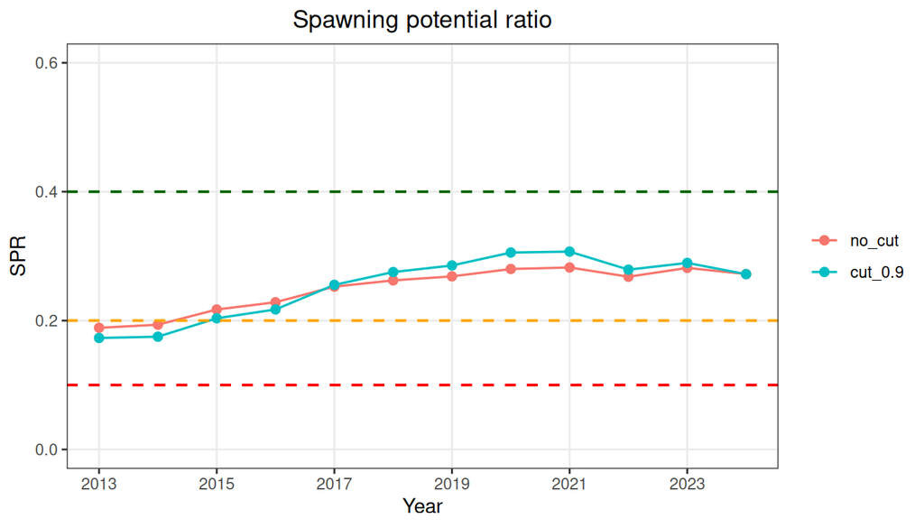

```r
f_none <- fitf(obs_model = "dm")
f_cut  <- fitf(obs_model = "dm", tail_cut = 0.9)
plot_spr(list(no_cut = f_none, cut_0.9 = f_cut))
```

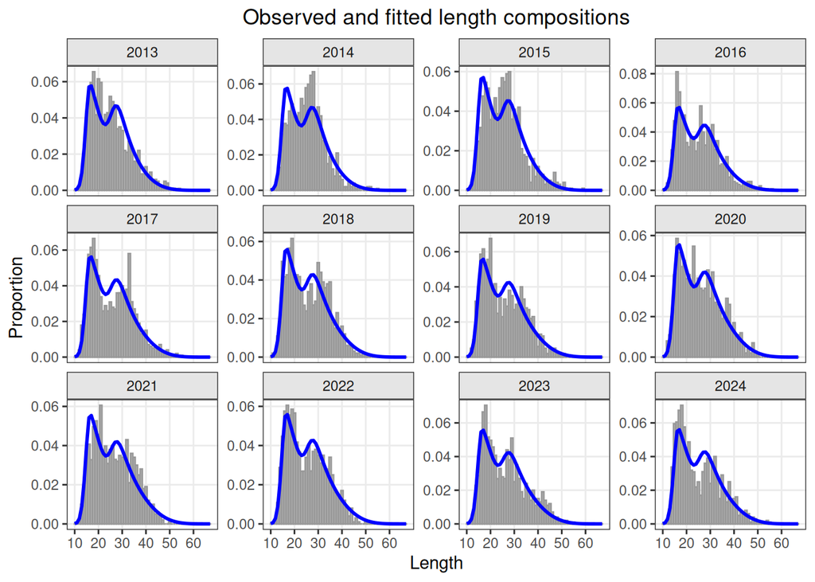

```r
plot_len(f_cut)   # predicted compositions are shown over all lengths
```

## 3.2 Interaction with `Lplus`

A plus group at or above the cut has no effect and is ignored with a warning:

```r
w <- tryCatch(fitf(obs_model = "dm", tail_cut = 0.9, Lplus = 54),
              warning = function(w) conditionMessage(w))
w
```

```
#> [1] "settings$Lplus lies at or above the tail cut; plus group ignored."
```

```r
check("Tail cut", "Lplus above the cut gives a warning", is.character(w))
```

```
#> PASS - Lplus above the cut gives a warning
```

```r
f_both <- fitf(obs_model = "dm", tail_cut = 1.0, Lplus = 45)
check("Tail cut", "Lplus below the cut works together with it", is.finite(lastspr(f_both)))
```

```
#> PASS - Lplus below the cut works together with it
```

## 3.3 Indicators follow the fit’s cut

`LBIspr()` and `LBImean()` read the cut from the fit, so observed and reference distributions use the same bins. `tail_cut = FALSE` uses all bins, a number overrides the fit’s cut.

```r
l_fit  <- LBIspr(f_cut)
l_all  <- LBIspr(f_cut, tail_cut = FALSE)
m_fit  <- LBImean(f_cut)
c(Lcut_LBIspr = attr(l_fit, "Lcut"), Lcut_LBImean = attr(m_fit, "Lcut"),
  Lcut_all = attr(l_all, "Lcut"))
```

```
#>  Lcut_LBIspr Lcut_LBImean     Lcut_all
#>           51           51           NA
```

```r
attr(l_fit, "Lref")
```

```
#>   Trawl Gillnet
#>      22      36
```

```r
check("Tail cut", "LBIspr uses the fit's cut", attr(l_fit, "Lcut") == f_cut$tmb_data$LLB[f_cut$tmb_data$cut_bin + 1])
```

```
#> PASS - LBIspr uses the fit's cut
```

```r
check("Tail cut", "LBImean uses the fit's cut", attr(m_fit, "Lcut") == attr(l_fit, "Lcut"))
```

```
#> PASS - LBImean uses the fit's cut
```

```r
check("Tail cut", "tail_cut = FALSE uses all bins", is.na(attr(l_all, "Lcut")))
```

```
#> PASS - tail_cut = FALSE uses all bins
```

```r
check("Tail cut", "reference lengths lie below the cut", all(attr(l_fit, "Lref") < attr(l_fit, "Lcut")))
```

```
#> PASS - reference lengths lie below the cut
```

```r
round(rbind(cut = c(index(l_fit[[1]])), all_bins = c(index(l_all[[1]]))), 3)
```

```
#>           [,1]  [,2]  [,3]  [,4]  [,5] [,6]  [,7]  [,8]  [,9] [,10] [,11] [,12]
#> cut      0.732 1.332 1.266 0.705 0.692 0.87 0.699 0.956 1.048 0.606 0.732 0.455
#> all_bins 0.732 1.332 1.266 0.705 0.692 0.87 0.699 0.956 1.048 0.606 0.732 0.455
```

# 4 Random walk on F as random effects (`settings$F_re`)

## 4.1 Why

By default, log F by year and gear are fixed effects with a random-walk penalty, estimated jointly with its standard deviation $\sigma_F$. Each step adds $-\log\sigma_F - (\Delta \log F)^2 / (2\sigma_F^2)$ to the log-likelihood, so the optimiser can smooth F and shrink $\sigma_F$ without limit; only the prior on $\sigma_F$ stops it collapsing to zero. The year-to-year pattern in F and SPR is then set largely by that prior.

With `F_re = TRUE`, log F are random effects integrated out by the Laplace approximation, so $\sigma_F$ is estimated from the marginal likelihood and standard errors include the F process. Without a user prior, a weak prior is used by default: `prior_sigmaF = c(log(0.3), 0.5, 1)`.

```r
f_pen   <- fitf(obs_model = "dm")                                   # penalised (default)
f_re    <- fitf(obs_model = "dm", F_re = TRUE)                      # prior from base
f_redef <- fiticc(lfd, stklen, sel_fun = sel_fun, catch_by_gear = cbg,
                  settings = list(CVL = 0.1, obs_model = "dm", F_re = TRUE))  # weak default prior
f_reno  <- fitf(obs_model = "dm", F_re = TRUE, prior_sigmaF = c(log(0.5), NA, 1))  # no prior

summ <- function(f) c(nll = round(f$opt$objective, 2), conv = f$opt$convergence,
                      pdHess = isTRUE(f$rep$pdHess), sigmaF = round(sigmaF_flicc(f), 3),
                      SPR_last = lastspr(f))
rbind(penalised = summ(f_pen), F_re_prior_0.5 = summ(f_re),
      F_re_default_prior = summ(f_redef), F_re_no_prior = summ(f_reno))
```

```
#>                         nll conv pdHess sigmaF SPR_last
#> penalised          35702.32    0      1  0.104   0.2722
#> F_re_prior_0.5     35748.80    0      1  0.191   0.2676
#> F_re_default_prior 35740.29    0      1  0.076   0.2732
#> F_re_no_prior      35731.79    0      1  0.000   0.2537
```

```r
check("F_re", "F_re fit is flagged and uses random effects", isTRUE(f_re$F_re))
```

```
#> PASS - F_re fit is flagged and uses random effects
```

```r
check("F_re", "F_re fits converge with a positive definite Hessian",
      f_re$opt$convergence == 0 && isTRUE(f_re$rep$pdHess))
```

```
#> PASS - F_re fits converge with a positive definite Hessian
```

```r
check("F_re", "weak default prior used when none is given",
      isTRUE(all.equal(c(f_redef$tmb_data$prior_sigmaF_mean, f_redef$tmb_data$prior_sigmaF_sd), c(log(0.3), 0.5))))
```

```
#> PASS - weak default prior used when none is given
```

```r
check("F_re", "prior_sigmaF with NA sd means no prior", f_reno$tmb_data$prior_sigmaF_sd == 0)
```

```
#> PASS - prior_sigmaF with NA sd means no prior
```

Note: the negative log-likelihoods of penalised and random-effects fits are not comparable (joint vs marginal likelihood).

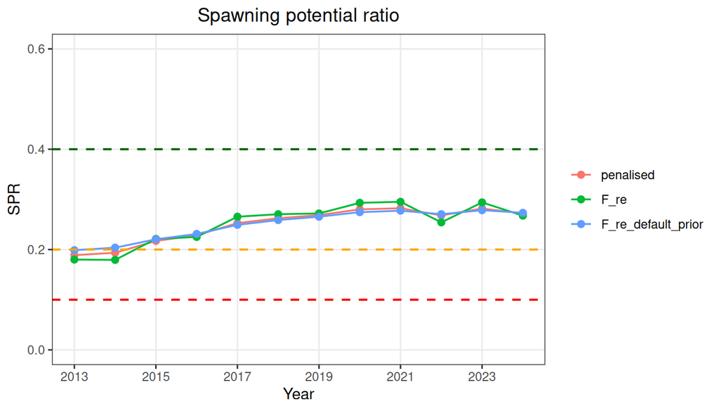

```r
plot_spr(list(penalised = f_pen, F_re = f_re, F_re_default_prior = f_redef))
```

## 4.2 Uncertainty includes the F process

```r
se_last <- function(f) { s <- summary(f$rep, "report"); tail(s[rownames(s) == "log_spr_y", 2], 1) }
round(c(penalised = se_last(f_pen), F_re = se_last(f_re)), 4)
```

```
#> penalised.log_spr_y      F_re.log_spr_y
#>              0.1022              0.1232
```

```r
check("F_re", "SE of log SPR is larger with F as random effects", se_last(f_re) > se_last(f_pen))
```

```
#> PASS - SE of log SPR is larger with F as random effects
```

`plot_spr(..., ci = TRUE)` adds 95% intervals, `exp(log(SPR) ± 1.96 SE)`, from the same standard errors (`spr_ci_flicc()` returns them as a table):

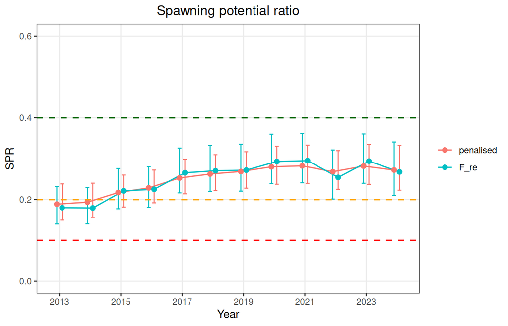

```r
plot_spr(list(penalised = f_pen, F_re = f_re), ci = TRUE)
```

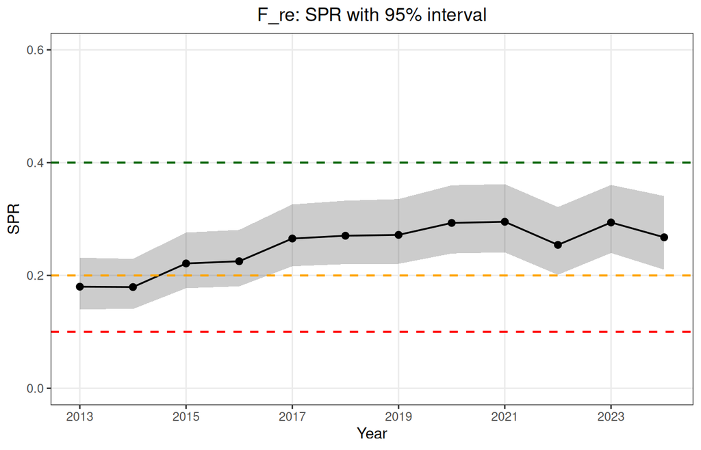

```r
plot_spr(f_re, ci = TRUE, ci_type = "ribbon", title = "F_re: SPR with 95% interval")
```

```r
ci_re <- spr_ci_flicc(f_re)
tail(ci_re, 3)
```

```
#>    year       spr    se_log       lwr       upr
#> 10 2022 0.2542586 0.1193329 0.2012331 0.3212566
#> 11 2023 0.2940283 0.1039432 0.2398350 0.3604673
#> 12 2024 0.2677076 0.1232192 0.2102695 0.3408356
```

```r
check("F_re", "spr_ci_flicc() intervals contain the estimates",
      all(ci_re$lwr < c(f_re$report$spr) & c(f_re$report$spr) < ci_re$upr))
```

```
#> PASS - spr_ci_flicc() intervals contain the estimates
```

```r
check("F_re", "spr_ci_flicc() returns NULL without standard errors",
      is.null(spr_ci_flicc(fitf(obs_model = "dm", se = FALSE))))
```

```
#> PASS - spr_ci_flicc() returns NULL without standard errors
```

## 4.3 Fast route: estimate $\sigma_F$ once, then fix it

Fitting with random effects takes several times longer. For repeated fits (e.g. inside an MSE), estimate $\sigma_F$ once with `F_re = TRUE` and fix it with `settings$sigmaF`; the SPR series closely reproduces the random-effects fit at the speed of the default.

```r
sig <- sigmaF_flicc(f_re)
f_fix <- fitf(obs_model = "dm", sigmaF = sig)
round(rbind(F_re = c(f_re$report$spr), sigmaF_fixed = c(f_fix$report$spr)), 3)
```

```
#>               [,1]  [,2]  [,3]  [,4]  [,5]  [,6]  [,7]  [,8]  [,9] [,10] [,11]
#> F_re         0.180 0.179 0.221 0.225 0.265 0.270 0.272 0.293 0.295 0.254 0.294
#> sigmaF_fixed 0.179 0.178 0.220 0.224 0.264 0.269 0.270 0.292 0.294 0.253 0.293
#>              [,12]
#> F_re         0.268
#> sigmaF_fixed 0.266
```

```r
dmax <- max(abs(c(f_fix$report$spr) - c(f_re$report$spr)))
dmax
```

```
#> [1] 0.001619936
```

```r
check("sigmaF", "sigmaF_flicc() returns the estimate", is.finite(sig) && sig > 0)
```

```
#> PASS - sigmaF_flicc() returns the estimate
```

```r
check("sigmaF", "fixed sigmaF is not estimated", !"log_sigmaF" %in% names(f_fix$opt$par))
```

```
#> PASS - fixed sigmaF is not estimated
```

```r
check("sigmaF", "sigmaF_flicc() returns the fixed value", abs(sigmaF_flicc(f_fix) - sig) < 1e-12)
```

```
#> PASS - sigmaF_flicc() returns the fixed value
```

```r
check("sigmaF", "fixed sigmaF reproduces the F_re SPR series (max diff < 0.01)", dmax < 0.01)
```

```
#> PASS - fixed sigmaF reproduces the F_re SPR series (max diff < 0.01)
```

## 4.4 Skipping standard errors (`se = FALSE`)

```r
f_nose <- fitf(obs_model = "dm", sigmaF = sig, se = FALSE)
check("se = FALSE", "no sdreport", is.null(f_nose$rep))
```

```
#> PASS - no sdreport
```

```r
check("se = FALSE", "same estimates as with sdreport",
      max(abs(c(f_nose$report$spr) - c(f_fix$report$spr))) < 1e-8)
```

```
#> PASS - same estimates as with sdreport
```

```r
check("se = FALSE", "downstream functions run",
      is.finite(fspr_flicc(f_nose)) && length(LBIspr(f_nose)) == 2)
```

```
#> PASS - downstream functions run
```

## 4.5 Timing

```r
tm <- function(...) system.time(fiticc(lfd, stklen, sel_fun = sel_fun, catch_by_gear = cbg, ...))[["elapsed"]]
s_dm <- modifyList(base, list(obs_model = "dm"))
round(c(penalised          = tm(settings = s_dm),
        F_re               = tm(settings = modifyList(s_dm, list(F_re = TRUE))),
        sigmaF_fixed       = tm(settings = modifyList(s_dm, list(sigmaF = sig))),
        sigmaF_fixed_no_se = tm(settings = modifyList(s_dm, list(sigmaF = sig)), se = FALSE)), 2)
```

```
#>          penalised               F_re       sigmaF_fixed sigmaF_fixed_no_se
#>               0.71               5.15               0.65               0.53
```

# 5 New features together and downstream functions

```r
f_all <- fitf(obs_model = "dm", tail_cut = 0.9, F_re = TRUE)
summ(f_all)
```

```
#>        nll       conv     pdHess     sigmaF   SPR_last
#> 35427.8200     0.0000     1.0000     0.2190     0.2621
```

```r
check("Combined", "tail cut and F_re fit together", f_all$opt$convergence == 0)
```

```
#> PASS - tail cut and F_re fit together
```

```r
b <- brp_tmb_flicc(f_all, spr = c(40, 20))
check("Combined", "Fspr from the fit and brp_tmb_flicc() agree", abs(fspr_flicc(f_all, spr = 40) - b$Fspr[1]) < 1e-8)
```

```
#> PASS - Fspr from the fit and brp_tmb_flicc() agree
```

```r
options(FLicc.brp_tmb = FALSE); f40_R <- fspr_flicc(f_all, spr = 40); options(FLicc.brp_tmb = TRUE)
check("Combined", "TMB and R reference points agree (rel. diff < 1e-3)", abs(b$Fspr[1] / f40_R - 1) < 1e-3)
```

```
#> PASS - TMB and R reference points agree (rel. diff < 1e-3)
```

```r
ok <- function(expr) !inherits(try(expr, silent = TRUE), "try-error")
check("Combined", "LBIspr()", ok(LBIspr(f_all)))
```

```
#> PASS - LBIspr()
```

```r
check("Combined", "LBImean()", ok(LBImean(f_all)))
```

```
#> PASS - LBImean()
```

```r
check("Combined", "flicc2FLStockR(s = 0.75)", ok(flicc2FLStockR(f_all, rel = TRUE, s = 0.75)))
```

```
#> PASS - flicc2FLStockR(s = 0.75)
```

```r
check("Combined", "eqstklen()", ok(eqstklen(f_all, s = 0.75)))
```

```
#> PASS - eqstklen()
```

```r
check("Combined", "flicc_convergence()", ok(flicc_convergence(f_all)))
```

```
#> PASS - flicc_convergence()
```

```r
check("Combined", "restart from the previous estimates (start argument)",
      ok(fiticc(lfd, stklen, sel_fun = sel_fun, catch_by_gear = cbg,
                settings = modifyList(base, list(obs_model = "dm", tail_cut = 0.9, F_re = TRUE)),
                start = f_all$opt$par)))
```

```
#> PASS - restart from the previous estimates (start argument)
```

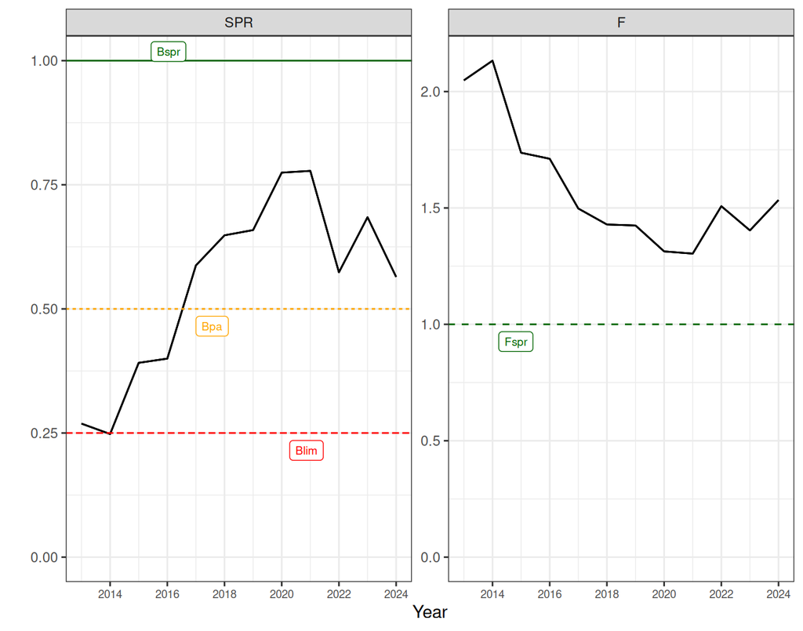

```r
plot_LBAdvice(flicc2FLStockR(f_all, rel = TRUE, s = 0.75))
```

# 6 MSE functions

From `dev-tailcut`. These need the operating model and run inside `mse::mp()`, so they are shown here but not run; please run the MP smoke test (`FLicc_lfd_mp_test.Rmd`) with a short horizon before merging.

- `flicc.sa()`: pass `tail_cut`, `F_re` or `sigmaF` through `settings`; `se = FALSE` through `...`.
- `lbi.hcr()` and `rfb.flicc.hcr()`: `trend = "track"` computes the trend ratio from the terminal-year values of previous cycles (tracked as `index.hcr`) instead of the current fit’s series; default `"fit"` keeps the previous behaviour. `rfb.flicc.hcr()` now defaults to `index = "SPR"`.
- `flicc.is()`: `Cmin`, a floor on the TAC the multiplier is applied to, so a multiplicative rule cannot get stuck near zero.

```r
sig <- sigmaF_flicc(fiticc(lfd, stklen, sel_fun = sel_fun, catch_by_gear = cbg,
                           settings = list(F_re = TRUE, tail_cut = 0.9)))
ctrl <- mpCtrl(list(
  est  = mseCtrl(method = flicc.sa,
                 args = list(lhpar = lhpar, sel_fun = sel_fun,
                             settings = list(pop_model = "gtg", obs_model = "dm",
                                             tail_cut = 0.9, sigmaF = sig),
                             se = FALSE)),
  hcr  = mseCtrl(method = rfb.flicc.hcr, args = list(index = "SPR", trend = "track")),
  isys = mseCtrl(method = flicc.is, args = list(initac = initac, Cmin = 0.1 * initac))))
```

`lfdess()` no longer returns `NaN` for empty gear-years:

```r
x <- lfd; x[[1]][, 1] <- 0
check("MSE", "lfdess() with an empty gear-year gives no NaN",
      !any(is.nan(unlist(lapply(lfdess(x, 100), c)))))
```

```
#> PASS - lfdess() with an empty gear-year gives no NaN
```

# 7 Continuous integration

Every push to a branch named `dev-*` or `ci-*` runs `.github/workflows/flicc-ci.yml`: it builds the branch and `main`, runs `test_dev.R` and the scripts in `ci/tests/`, compares default fits with `main`, renders changed `.Rmd` files, and publishes the results to the branch `ci-out/<branch>` (`summary.md`, logs, html). See `ci/README.md`.

# 8 Summary of checks

```r
knitr::kable(checks, row.names = FALSE)
```

| section | check | pass |
| --- | --- | --- |
| Defaults | default mn fit matches main | TRUE |
| Defaults | default dm fit matches main | TRUE |
| Defaults | default nb fit matches main | TRUE |
| Defaults | no tail cut by default | TRUE |
| Defaults | F is not a random effect by default | TRUE |
| Tail cut | cut at 0.9 Linf starts at the first bin with lower bound >= 0.9 * 55.7 | TRUE |
| Tail cut | all observation models fit with a cut | TRUE |
| Tail cut | Lplus above the cut gives a warning | TRUE |
| Tail cut | Lplus below the cut works together with it | TRUE |
| Tail cut | LBIspr uses the fit’s cut | TRUE |
| Tail cut | LBImean uses the fit’s cut | TRUE |
| Tail cut | tail_cut = FALSE uses all bins | TRUE |
| Tail cut | reference lengths lie below the cut | TRUE |
| F_re | F_re fit is flagged and uses random effects | TRUE |
| F_re | F_re fits converge with a positive definite Hessian | TRUE |
| F_re | weak default prior used when none is given | TRUE |
| F_re | prior_sigmaF with NA sd means no prior | TRUE |
| F_re | SE of log SPR is larger with F as random effects | TRUE |
| F_re | spr_ci_flicc() intervals contain the estimates | TRUE |
| F_re | spr_ci_flicc() returns NULL without standard errors | TRUE |
| sigmaF | sigmaF_flicc() returns the estimate | TRUE |
| sigmaF | fixed sigmaF is not estimated | TRUE |
| sigmaF | sigmaF_flicc() returns the fixed value | TRUE |
| sigmaF | fixed sigmaF reproduces the F_re SPR series (max diff < 0.01) | TRUE |
| se = FALSE | no sdreport | TRUE |
| se = FALSE | same estimates as with sdreport | TRUE |
| se = FALSE | downstream functions run | TRUE |
| Combined | tail cut and F_re fit together | TRUE |
| Combined | Fspr from the fit and brp_tmb_flicc() agree | TRUE |
| Combined | TMB and R reference points agree (rel. diff < 1e-3) | TRUE |
| Combined | LBIspr() | TRUE |
| Combined | LBImean() | TRUE |
| Combined | flicc2FLStockR(s = 0.75) | TRUE |
| Combined | eqstklen() | TRUE |
| Combined | flicc_convergence() | TRUE |
| Combined | restart from the previous estimates (start argument) | TRUE |
| MSE | lfdess() with an empty gear-year gives no NaN | TRUE |

```r
cat(sum(checks$pass), "of", nrow(checks), "checks passed\n")
```

```
#> 37 of 37 checks passed
```

```r
stopifnot("some checks failed - see the table above" = all(checks$pass))
```